# Data selection

Federico Deotto

2024-03-12

#SUMMARY The first challenge we faced was the high number of variables, necessitating reduction. To tackle this, I conducted PCA on the covariate matrix and employed the elbow criterion to select the first 4 components. Subsequently, I identified the variables that primarily contributed to these principal components. This led to a significant reduction in dimensionality, nearly halving the number of variables. However, it’s essential to note that this method doesn’t consider time and assumes linear relationships between variables.

Following this, I calculated the Spearman correlation matrix on the union_variable and pinpointed highly correlated variables. This insight may be valuable in a subsequent phase for addressing multicollinearity during modeling.

Finally, I saved the intersection and union of the coefficients selected using the three different approaches.

```r
# Read data
data <- read_csv('data_cleaned_UTC.csv')
df <- data
```

##Covariates

#PCA The initial segment of the code pertains to the analysis of covariates (data), primarily focusing on their reduction.

Perform PCA on covariates, select the first four pc based on elbow criterion. Plot for each of the PC the histogram of loadings.

```r
data <- data %>% #covariates
  select(-c(day_ahead_price_de, date))

pca_data <- pca(data, scale. = T, center = T)
```

[output not shown]

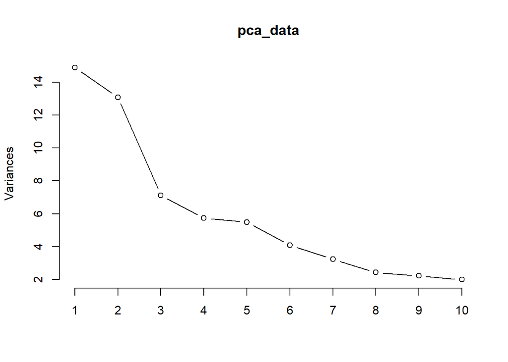

```r
plot(pca_data, type = 'l') #4 component
```

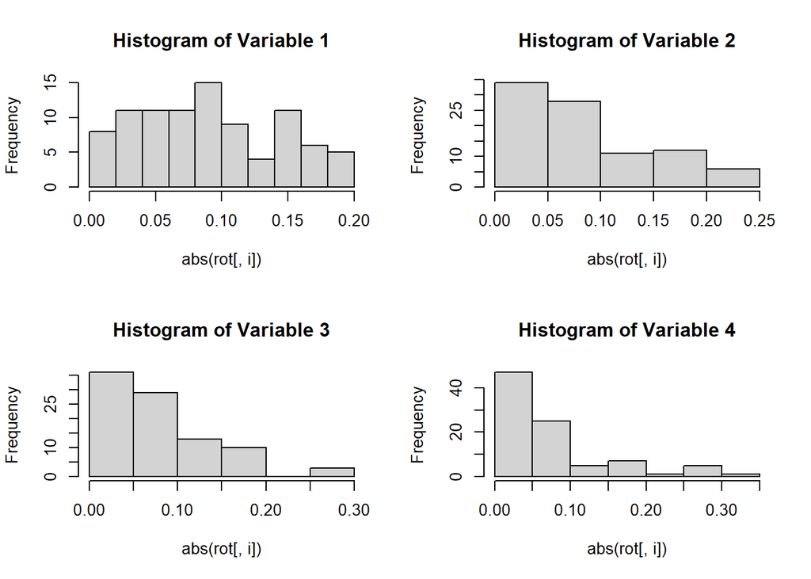

```r
rot <- pca_data$rotation[, 1:4]
par(mfrow = c(2,2))
for (i in 1:ncol(rot)) {
  hist(abs(rot[, i]), main = paste("Histogram of Variable", i))
}
```

```r
par(mfrow = c(1,1))
```

Select the most relavant variables in the first 4 pc, based on arbitrary tresholds (histograms)

```r
cond1 <- abs(rot[,1:2]) > 0.15
cond2 <- abs(rot[,3:4]) > 0.17
matr <- cbind(cond1, cond2)
cond <- rowSums(matr)
pca_coef <- rownames(matr[cond == 1, ])

rm(cond1, cond2, matr, cond, rot, i, pca_data)
```

Split train and test

```r
start_date = min(df$date)
split_date = ymd_hm("2020-01-01 00:00")
end_date = ymd_hm("2021-01-01 00:00")

dt_train = df |>
  filter(date > start_date) |>
  filter(date < split_date) |>
  filter(date < end_date)

dt_test = df |>
  filter(date > start_date) |>
  filter(date >= split_date) |>
  filter(date < end_date)
```

```r
# Create recipe
lasso_rec = recipe(day_ahead_price_de ~ ., data = dt_train) |>
  step_mutate(hour = hour(date)) |>
  step_date(date) |>
  update_role(date, new_role = "date") |>
  step_zv(all_predictors()) |>
  step_center(all_numeric_predictors()) |>
  step_scale(all_numeric_predictors()) |>
  step_dummy(all_nominal_predictors())

lasso_rec |> prep() |> juice()
```

```
## # A tibble: 8,758 × 111
##    date                auction…¹ alloc…² ATC_c…³ day_a…⁴ day_a…⁵ day_a…⁶ actua…⁷
##    <dttm>                  <dbl>   <dbl>   <dbl>   <dbl>   <dbl>   <dbl>   <dbl>
##  1 2019-01-01 00:00:00    -0.283   0.828   0.824 -0.0229   0.634  0.486   -0.974
##  2 2019-01-01 01:00:00    -0.283   0.828   0.824 -0.0214   0.513  0.0235  -1.14
##  3 2019-01-01 02:00:00    -0.283   0.828   0.824 -0.931   -0.375 -0.826   -1.36
##  4 2019-01-01 03:00:00    -0.283   0.828   0.824 -3.09    -0.878 -1.16    -1.39
##  5 2019-01-01 04:00:00    -0.283   0.828   0.824 -3.40    -1.10  -1.20    -1.27
##  6 2019-01-01 05:00:00    -0.283   0.828   0.824 -3.75    -1.00  -1.32    -1.22
##  7 2019-01-01 06:00:00    -0.283   0.828   0.824 -3.52    -1.14  -0.921   -0.905
##  8 2019-01-01 07:00:00    -0.283   0.828   0.824 -2.94    -0.990 -1.03    -0.721
##  9 2019-01-01 08:00:00    -0.283   0.828   0.824 -3.03    -0.423 -1.03    -0.475
## 10 2019-01-01 09:00:00    -0.283   0.828   0.824 -1.96    -0.274 -0.343   -0.230
## # … with 8,748 more rows, 103 more variables: actual_load_ch <dbl>,
## #   actual_load_de <dbl>, actual_load_fr <dbl>, actual_load_it <dbl>,
## #   solar_forecast_de <dbl>, wind_onshore_forecast_fr <dbl>,
## #   biomass_actual_aggregated_at <dbl>, fossil_gas_actual_aggregated_at <dbl>,
## #   fossil_hard_coal_actual_aggregated_at <dbl>,
## #   hydro_pumped_storage_actual_aggregated_at <dbl>,
## #   hydro_pumped_storage_actual_consumption_at <dbl>, …
```

```r
summary(lasso_rec) |> as.data.frame()
```

```
##                                                variable            type
## 1                                                  date        datetime
## 2                                   auction_price_ch_de double, numeric
## 3                               allocatedCapacity_ch_de double, numeric
## 4                                             ATC_ch_de double, numeric
## 5                                    day_ahead_price_at double, numeric
## 6                                    day_ahead_price_ch double, numeric
## 7                                    day_ahead_price_fr double, numeric
## 8                                        actual_load_at double, numeric
## 9                                        actual_load_ch double, numeric
## 10                                       actual_load_de double, numeric
## 11                                       actual_load_fr double, numeric
## 12                                       actual_load_it double, numeric
## 13                                    solar_forecast_de double, numeric
## 14                             wind_onshore_forecast_fr double, numeric
```

[output cut: 173 more lines]

```r
# Setting up the tuning grid
lasso_grid <- seq(0.00001, 0.2, length.out = 25)

# Tune the parameter
train_metrics = c()
test_metrics = c()

fit_lasso = function(alpha){
  # Setting up specifications
  lasso_spec = linear_reg(mixture = 1, penalty = alpha) %>%
    set_mode("regression") %>%
    set_engine("glmnet")

  # Setting up workflow
  lasso_wflow = workflow() |>
    add_model(lasso_spec) |>
    add_recipe(lasso_rec)

  # Fit the model with parameter
  lasso_fit = lasso_wflow |>
    fit(dt_train)
}

for (i in 1:length(lasso_grid)){

  # Fit lasso with parameter
  lasso_fit = fit_lasso(alpha = lasso_grid[i])

  # Make predictions and store the metric
  train_metrics = append(
    train_metrics,
    lasso_fit |>
      predict(dt_train) |>
      mutate(actual = dt_train$day_ahead_price_de) |>
      rmse(actual, .pred) |>
      pull(.estimate)
  )

  test_metrics = append(
    test_metrics,
    lasso_fit |>
      predict(dt_test) |>
      mutate(actual = dt_test$day_ahead_price_de) |>
      rmse(actual, .pred) |>
      pull(.estimate)
  )

  print(paste(i, "done out of", length(lasso_grid)))
}
```

[output not shown]

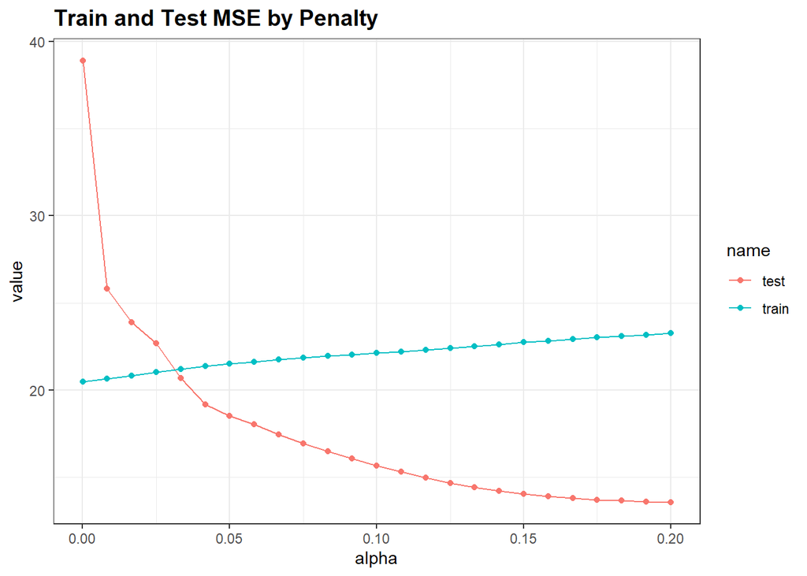

```r
tuning_results = tibble(
  alpha = lasso_grid,
  train = train_metrics,
  test = test_metrics
)

tuning_results |>
  pivot_longer(-alpha) |>
  mutate(value = value^2) |>
  ggplot(aes(alpha, value, colour = name)) +
  geom_line() +
  geom_point() +
  labs(title = "Train and Test MSE by Penalty")
```

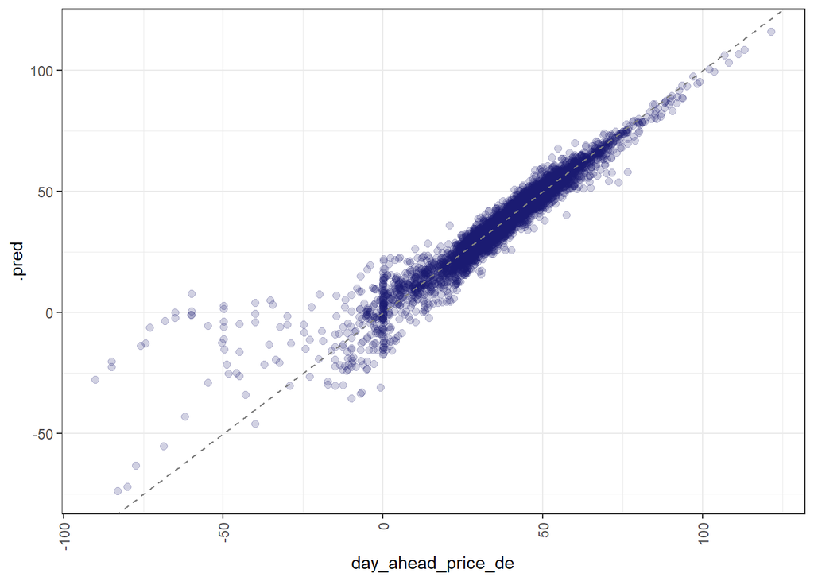

```r
# Fitting the model
lasso_fit = fit_lasso(alpha = lasso_grid[5]) #intersect test and train

# Predictions vs actuals in-sample
lasso_fit |>
  augment(dt_train) |>
  ggplot(aes(day_ahead_price_de, .pred)) +
  geom_point(alpha = 0.2, colour = "midnightblue", size = 2) +
  geom_abline(lty = "dashed", colour = "grey50") +
  scale_x_continuous(labels = scales::comma_format()) +
  scale_y_continuous(labels = scales::comma_format()) +
  theme_bw() +
  theme(axis.text.x = element_text(angle = 90, hjust = 1, vjust = 0.5))
```

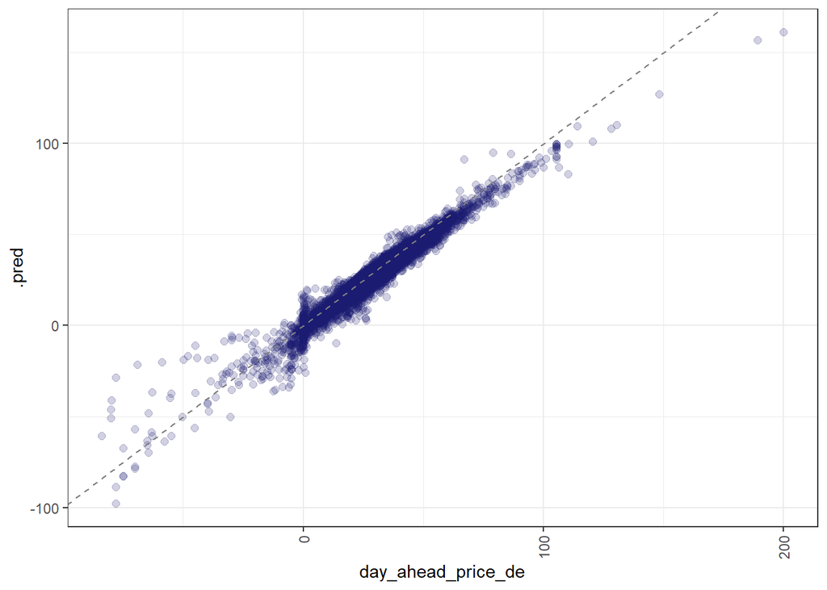

```r
# Predictions vs actuals out-of-sample
lasso_fit |>
  augment(dt_test) |>
  ggplot(aes(day_ahead_price_de, .pred)) +
  geom_point(alpha = 0.2, colour = "midnightblue", size = 2) +
  geom_abline(lty = "dashed", colour = "grey50") +
  scale_x_continuous(labels = scales::comma_format()) +
  scale_y_continuous(labels = scales::comma_format()) +
  theme_bw() +
  theme(axis.text.x = element_text(angle = 90, hjust = 1, vjust = 0.5))
```

```r
# Get the variables that remained in the model
lasso_coef <- lasso_fit |>
  tidy() |>
  filter(estimate > 0,
         ! str_detect(term, "Intercept")) |>
  pull(term)
```

### Variable Importance with Random Forest

Should give a general impression of which variables might be important

```r
# Create recipe
rf_rec = recipe(day_ahead_price_de ~ ., data = dt_train) |>
  step_mutate(hour = hour(date)) |>
  step_date(date) |>
  update_role(date, new_role = "date") |>
  step_zv(all_predictors()) |>
  step_center(all_numeric_predictors()) |>
  step_scale(all_numeric_predictors())

rf_rec |> prep() |> juice()
```

```
## # A tibble: 8,758 × 96
##    date                auction…¹ alloc…² ATC_c…³ day_a…⁴ day_a…⁵ day_a…⁶ actua…⁷
##    <dttm>                  <dbl>   <dbl>   <dbl>   <dbl>   <dbl>   <dbl>   <dbl>
##  1 2019-01-01 00:00:00    -0.283   0.828   0.824 -0.0229   0.634  0.486   -0.974
##  2 2019-01-01 01:00:00    -0.283   0.828   0.824 -0.0214   0.513  0.0235  -1.14
##  3 2019-01-01 02:00:00    -0.283   0.828   0.824 -0.931   -0.375 -0.826   -1.36
##  4 2019-01-01 03:00:00    -0.283   0.828   0.824 -3.09    -0.878 -1.16    -1.39
##  5 2019-01-01 04:00:00    -0.283   0.828   0.824 -3.40    -1.10  -1.20    -1.27
##  6 2019-01-01 05:00:00    -0.283   0.828   0.824 -3.75    -1.00  -1.32    -1.22
##  7 2019-01-01 06:00:00    -0.283   0.828   0.824 -3.52    -1.14  -0.921   -0.905
##  8 2019-01-01 07:00:00    -0.283   0.828   0.824 -2.94    -0.990 -1.03    -0.721
##  9 2019-01-01 08:00:00    -0.283   0.828   0.824 -3.03    -0.423 -1.03    -0.475
## 10 2019-01-01 09:00:00    -0.283   0.828   0.824 -1.96    -0.274 -0.343   -0.230
## # … with 8,748 more rows, 88 more variables: actual_load_ch <dbl>,
## #   actual_load_de <dbl>, actual_load_fr <dbl>, actual_load_it <dbl>,
## #   solar_forecast_de <dbl>, wind_onshore_forecast_fr <dbl>,
## #   biomass_actual_aggregated_at <dbl>, fossil_gas_actual_aggregated_at <dbl>,
## #   fossil_hard_coal_actual_aggregated_at <dbl>,
## #   hydro_pumped_storage_actual_aggregated_at <dbl>,
## #   hydro_pumped_storage_actual_consumption_at <dbl>, …
```

```r
summary(rf_rec) |> as.data.frame()
```

```
##                                                variable            type
## 1                                                  date        datetime
## 2                                   auction_price_ch_de double, numeric
## 3                               allocatedCapacity_ch_de double, numeric
## 4                                             ATC_ch_de double, numeric
## 5                                    day_ahead_price_at double, numeric
## 6                                    day_ahead_price_ch double, numeric
## 7                                    day_ahead_price_fr double, numeric
## 8                                        actual_load_at double, numeric
## 9                                        actual_load_ch double, numeric
## 10                                       actual_load_de double, numeric
## 11                                       actual_load_fr double, numeric
## 12                                       actual_load_it double, numeric
## 13                                    solar_forecast_de double, numeric
## 14                             wind_onshore_forecast_fr double, numeric
```

[output cut: 173 more lines]

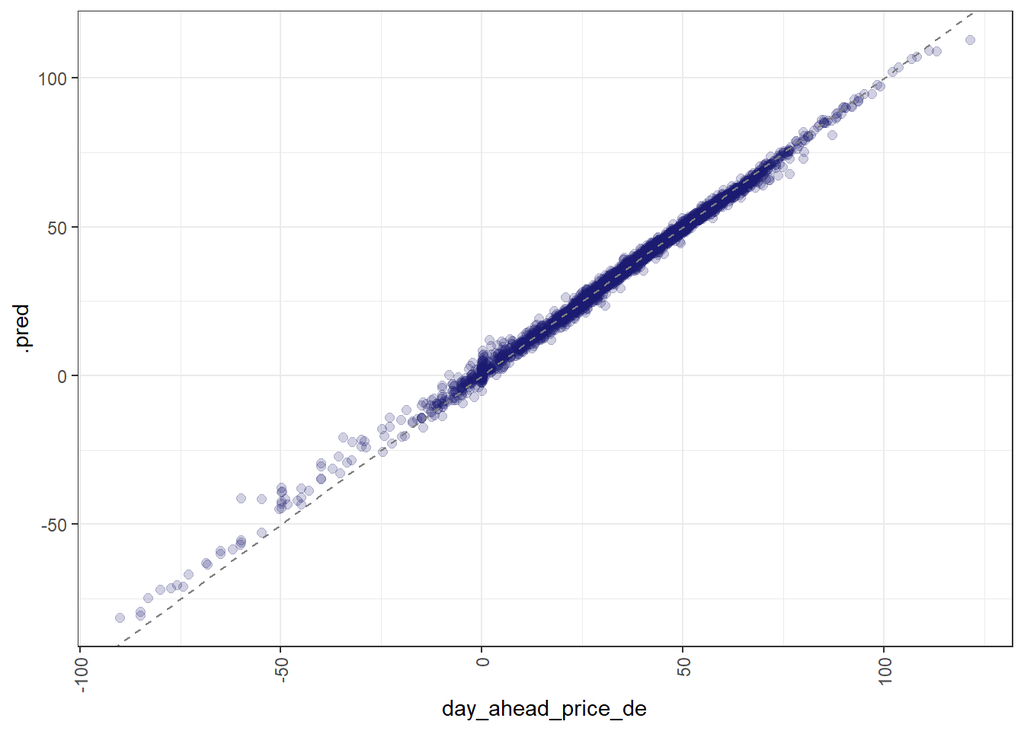

```r
# Setting up specifications
rf_spec = rand_forest() |>
  set_engine("ranger", importance = "impurity") |>
  set_mode("regression")

# Setting up workflow
rf_wflow = workflow() |>
  add_model(rf_spec) |>
  add_recipe(rf_rec)

# Fitting the model
rf_fit = rf_wflow |>
  fit(dt_train)

# Predictions vs actuals in-sample
rf_fit |>
  augment(dt_train) |>
  ggplot(aes(day_ahead_price_de, .pred)) +
  geom_point(alpha = 0.2, colour = "midnightblue", size = 2) +
  geom_abline(lty = "dashed", colour = "grey50") +
  scale_x_continuous(labels = scales::comma_format()) +
  scale_y_continuous(labels = scales::comma_format()) +
  theme_bw() +
  theme(axis.text.x = element_text(angle = 90, hjust = 1, vjust = 0.5))
```

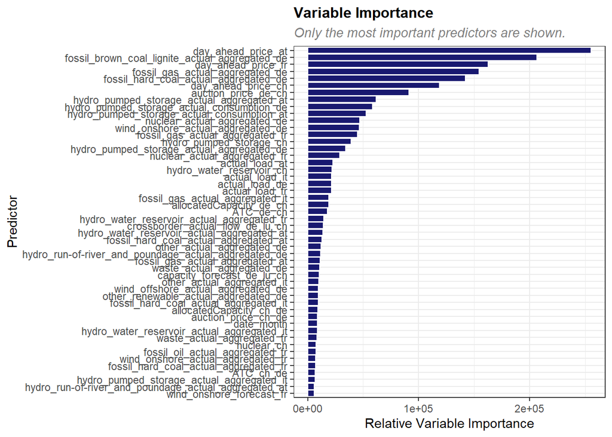

```r
# Get feature importance
rf_fit |>
  extract_fit_parsnip() |>
  vip::vi() |>
  as_tibble() |>
  slice_max(order_by = Importance, n = 50) %>%
  ggplot(aes(Importance, reorder(Variable, Importance))) +
  geom_col(fill = "midnightblue", colour = "white") +
  labs(title = "Variable Importance",
       subtitle = "Only the most important predictors are shown.",
       y = "Predictor",
       x = "Relative Variable Importance") +
  theme_bw() +
  theme(plot.title = element_text(face = "bold", size = 12),
        plot.subtitle = element_text(face = "italic", colour = "grey50"))
```

```r
boost_coef <- rf_fit |>
  extract_fit_parsnip() |>
  vip::vi() |>
  as_tibble() |>
  slice_max(order_by = Importance, n = 20) %>%
  select(Variable)
```

Select the union of the variables select with the 3 different models

```r
union_coef <- union(lasso_coef, boost_coef) %>% unlist()
(union_coef <- union(union_coef, pca_coef) %>% sort())
```

```
##  [1] "actual_load_at"
##  [2] "actual_load_ch"
##  [3] "actual_load_de"
##  [4] "actual_load_fr"
##  [5] "actual_load_it"
##  [6] "allocatedCapacity_ch_de"
##  [7] "allocatedCapacity_de_ch"
##  [8] "ATC_ch_de"
##  [9] "ATC_de_ch"
## [10] "auction_price_ch_de"
## [11] "auction_price_de_ch"
## [12] "biomass_actual_aggregated_at"
## [13] "biomass_actual_aggregated_de"
## [14] "capacity_forecast_ch_at"
## [15] "capacity_forecast_it_ch"
```

[output cut: 49 more lines]

```r
intersect_coef <- intersect(pca_coef, boost_coef$Variable)
(intersect_coef <- intersect(lasso_coef, intersect_coef) %>% sort())
```

```
## [1] "day_ahead_price_ch"
## [2] "day_ahead_price_fr"
## [3] "fossil_brown_coal_lignite_actual_aggregated_de"
## [4] "fossil_gas_actual_aggregated_de"
## [5] "hydro_pumped_storage_actual_aggregated_at"
```

```r
#Consider again the full dataset
data <- read.csv('data_cleaned_UTC.csv')  #hydro ecc why not present same file?
```

#Spearman

Look into Spearman correlation. The covariates are themselves time series, so watch out to spurious correlation.

```r
cond <- union_coef %in% colnames(data)
temporary <- union_coef[!cond] %>% tibble() %>%
  filter(!str_detect(., 'date')) %>%
  filter(!str_detect(., 'hour'))
names(temporary) <- 'Column_Name'
temp <- temporary$Column_Name
temporary <- temporary %>%
  mutate(Column_Name = str_replace_all(Column_Name, "-", "."))
```

```r
cond <- union_coef %in% temp
union_coef[cond] <- temporary$Column_Name
```

```r
cond <- union_coef %in% colnames(data) #hour or day
union_coef2 <- union_coef[cond]

# Compute Spearman correlation matrix
temporary <- data %>%
  select(all_of(union_coef2))
cor_matrix <- cor(temporary, method = "spearman", use = "pairwise.complete.obs")
threshold <- 0.7

# Find pairs of variables with correlation greater than the threshold
high_corr_pairs <- which(abs(cor_matrix) > threshold & cor_matrix != 1, arr.ind = TRUE)

# Get variable names for the pairs
variable_names <- colnames(data)

# Initialize an empty vector to store pairs information
pairs_info <- character(nrow(high_corr_pairs))

# Fill the vector with pairs information
for (i in 1:nrow(high_corr_pairs)) {
  var1 <- variable_names[high_corr_pairs[i, 1]]
  var2 <- variable_names[high_corr_pairs[i, 2]]
  pairs_info[i] <- paste(var1, ",", var2)
}
pairs_info
```

```
##  [1] "auction_price_ch_de , date"
##  [2] "allocatedCapacity_ch_de , date"
##  [3] "ATC_ch_de , date"
##  [4] "day_ahead_price_at , date"
##  [5] "date , auction_price_ch_de"
##  [6] "ATC_ch_de , auction_price_ch_de"
##  [7] "date , allocatedCapacity_ch_de"
##  [8] "ATC_ch_de , allocatedCapacity_ch_de"
##  [9] "day_ahead_price_at , allocatedCapacity_ch_de"
## [10] "date , ATC_ch_de"
## [11] "auction_price_ch_de , ATC_ch_de"
## [12] "allocatedCapacity_ch_de , ATC_ch_de"
## [13] "wind_onshore_actual_aggregated_at , ATC_ch_de"
## [14] "hydro_run.of.river_and_poundage_ch , ATC_ch_de"
## [15] "fossil_oil_actual_aggregated_fr , ATC_ch_de"
```

[output cut: 56 more lines]

Names of variables highly correlated, maybe can arose multicollinearity from them, pairs_info

```r
writeLines(intersect_coef, "intersect_coef.txt")
writeLines(union_coef, "union_coef.txt")
```